# NFL Data Exploration

## Investigation Overview

> The goal of this presentation is to look at the various factors that affect NFL QB rating

## Dataset Overview

> I used the NFL QB career stats dataset for this project. This dataset contains passing stats for every player who has ever thrown a pass in an nfl game

```python
# import all packages and set plots to be embedded inline
import numpy as np
import pandas as pd
import matplotlib.pyplot as plt
import seaborn as sb

%matplotlib inline

# suppress warnings from final output
import warnings
warnings.simplefilter("ignore")
```

```python
# load in the dataset into a pandas dataframe
career_stats_qb = pd.read_csv('Career_Stats_Passing.csv');
```

```python
career_stats_qb = career_stats_qb.drop(['Player Id', 'Position', 'Year', 'Team'], axis=1)
```

```python
career_stats_qb = career_stats_qb.apply(pd.to_numeric, errors='ignore')
```

```python
career_stats_qb['Ratings/game'] = career_stats_qb['Passer Rating']/career_stats_qb['Games Played']
```

```python
career_stats_qb = career_stats_qb.dropna()
```

```python
career_stats_qb = career_stats_qb.sort_values(by ='Ratings/game', ascending=False )
```

```python
career_stats_qb.rename(columns = {'Passes Attempted':'Passes_Attempted', 'Games Played' : 'Games_Played', 'Passes Completed' : 'Passes_Completed', 'Completion Percentage' : 'Completion_Percentage', 'Pass Attempts Per Game' : 'Pass_Attempts_Per_Game', 'Passing Yards' : 'Passing_Yards', 'Passing Yards Per Attempt' : 'Passing_Yards_Per_Attempt', 'Passing Yards Per Game' : 'Passing_Yards_Per_Game', 'TD Passes' : 'TD_Passes', 'Percentage of TDs per Attempts' : 'Percentage_of_TDs_per_Attempts', 'Int Rate' : 'Int_Rate', 'Longest Pass' : 'Longest_Pass', 'Passes Longer than 20 Yards' : 'Passes_Longer_than_20_Yards', 'Passes Longer than 40 Yards' : 'Passes_Longer_than_40_Yards', 'Sacked Yards Lost' : 'Sacked_Yards_Lost', 'Passer Rating' : 'Passer_Rating'}, inplace = True)
```

```python
career_stats_qb = career_stats_qb.replace({'--': 0}, regex=True)
```

```python
career_stats_qb = career_stats_qb[career_stats_qb.loc[:]!=0].dropna()
```

```python
career_stats_qb = career_stats_qb.apply(pd.to_numeric, errors='ignore')
```

```python
career_stats_qb[['Passing_Yards', 'Longest_Pass']] = career_stats_qb[['Passing_Yards', 'Longest_Pass']].apply(pd.to_numeric, errors='coerce')
```

```python
career_stats_qb_clean = career_stats_qb.query('Passes_Attempted > 100 and Games_Played > 10')
```

```python
career_stats_qb_clean = career_stats_qb_clean.drop(['Passing_Yards'], axis = 1)
```

```python
career_stats_qb_clean_new = career_stats_qb_clean.drop(['Name', 'Passes_Completed','Pass_Attempts_Per_Game', 'Passing_Yards_Per_Game', 'Percentage_of_TDs_per_Attempts', 'Int_Rate', 'Longest_Pass', 'Passes_Longer_than_20_Yards', 'Passes_Longer_than_40_Yards', 'Sacks', 'Sacked_Yards_Lost', 'Passer_Rating'], axis=1);
```

```python
career_stats_qb_clean_new.corr();
```

```python
# Create Ranking Based On Average Completion Rate
career_stats_qb_clean_new["Completion_Rank"] = np.where(career_stats_qb_clean_new.Completion_Percentage > career_stats_qb_clean_new.Completion_Percentage.mean(),
      "Above Average", "Below Average")
```

## Ratings/game vs Passes Attempted

> To get an idea of what a resonable cut off would be for passes attempted I will plot Ratings/game vs passes attempted

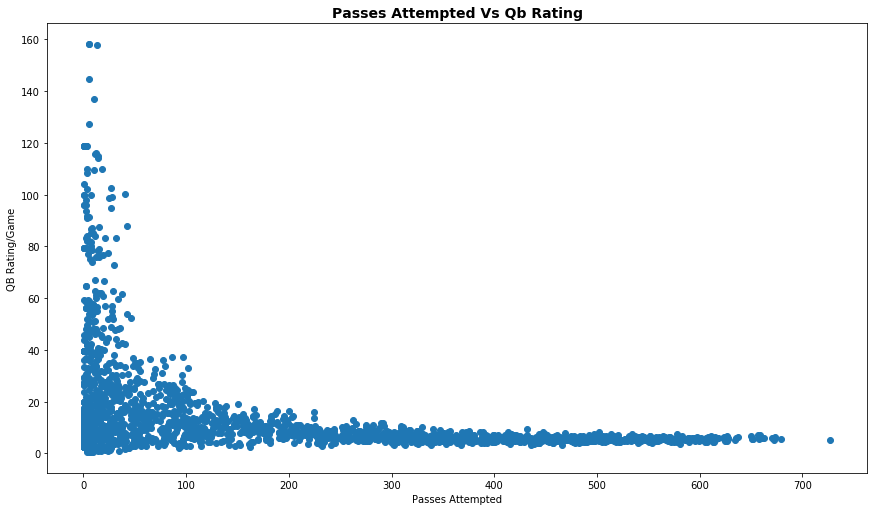

```python
# Scatterplot -  Ratings/game vs Passes Attempted

plt.figure(figsize=[14.70, 8.27])
plt.scatter(career_stats_qb['Passes_Attempted'], career_stats_qb['Ratings/game']);
plt.xlabel("Passes Attempted")
plt.ylabel("QB Rating/Game");
plt.title("Passes Attempted Vs QB Rating".title(), fontsize = 14, weight = "bold" );
```

## Ratings/game vs games played

> To get an idea of what a resonable cut off would be for games played I will plot Ratings/game vs games played

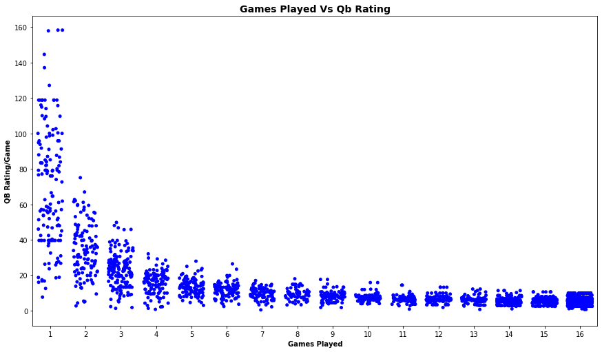

```python
# Scatterplot - Ratings/game vs Games played

plt.figure(figsize=[14.70, 8.27])
sb.stripplot(career_stats_qb['Games_Played'],
            career_stats_qb['Ratings/game'],
            jitter = 0.35, color = "blue");
plt.xlabel("Games Played", fontsize = 10, weight = "bold");
plt.ylabel("QB Rating/Game", fontsize = 10, weight = "bold");
plt.title("Games Played Vs QB Rating".title(), fontsize = 14, weight = "bold" );
```

## Ratings/game vs Completion %

> I also want to look at Completion Percentage versus QB Rating

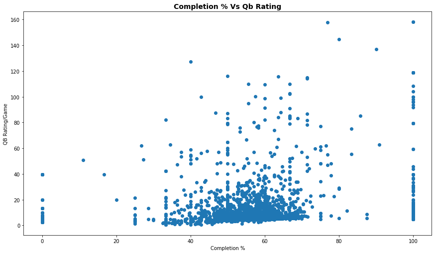

```python
# Scatterplot -  Ratings/game vs Completion %

plt.figure(figsize=[14.70, 8.27])
plt.scatter(career_stats_qb['Completion_Percentage'], career_stats_qb['Ratings/game']);
plt.xlabel("Completion %")
plt.ylabel("QB Rating/Game");
plt.title("Completion % Vs QB Rating".title(), fontsize = 14, weight = "bold" );
```

## Ratings/game vs Passes Attempted with completion rank

> Now that I have removed any data corresponding to fewer then 100 passes attempted in a season I will again plot passes attempted versus qb rating.

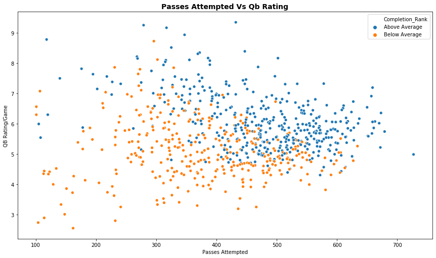

```python
# Scatterplot -  Ratings/game vs Passes Attempted with completion rank

plt.figure(figsize=[14.70, 8.27])
sb.scatterplot(data = career_stats_qb_clean_new, x = 'Passes_Attempted', y = 'Ratings/game', hue = 'Completion_Rank');
plt.xlabel("Passes Attempted")
plt.ylabel("QB Rating/Game");
plt.title("Passes Attempted Vs QB Rating".title(), fontsize = 14, weight = "bold" );
```

## Ratings per game vs Passing Yards per Attempt with Completion Rank

> Now that I have removed any data corresponding to fewer then 10 games played in a season I will again plot Passing Yards per Attempt versus qb rating.

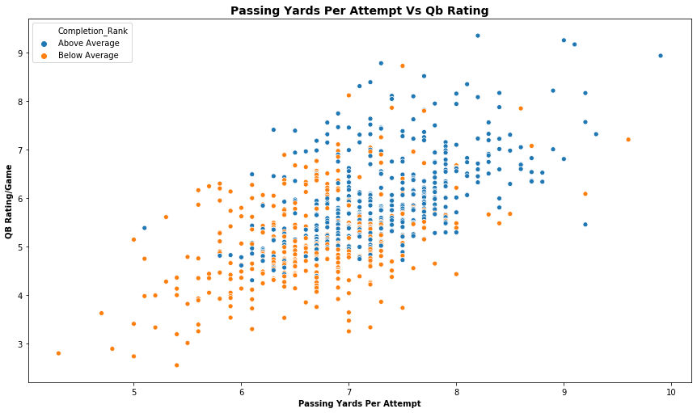

```python
# Scatterplot Ratings per game vs Passing Yards per Attempt with Completion Rank

plt.figure(figsize=[14.70, 8.27])
sb.scatterplot(data = career_stats_qb_clean_new, x = 'Passing_Yards_Per_Attempt', y = 'Ratings/game', hue = 'Completion_Rank');
plt.xlabel("Passing Yards Per Attempt", fontsize = 10, weight = "bold");
plt.ylabel("QB Rating/Game", fontsize = 10, weight = "bold");
plt.title("Passing Yards per Attempt Vs QB Rating".title(), fontsize = 14, weight = "bold" );
```

## Scatterplots with Linear Regression lines

> This is a series of graphs showing qb rating versus the following variables, games played, passes attempted, passing yards per attempt, TD passes, Ints. I included a linear regression line on each graph to give an idea of how well the graph fit the data.

[figure not shown]

```python
# Scatterplots with Linear Regression lines
sb.pairplot(career_stats_qb_clean_new, y_vars = ['Ratings/game'], x_vars = ['Games_Played', 'Completion_Percentage', 'Passes_Attempted', 'Passing_Yards_Per_Attempt', 'TD_Passes', 'Ints'], kind="reg", height = 8.27,  aspect = 14.70/8.27);
plt.show();
```

## Heatmap of all relevant variables

> This is a heatmap showing how all of the variables in my dataset are correlated with each other. The numbers in each box represent the strength of the relation between the different variables, with 1 being the best match possible.

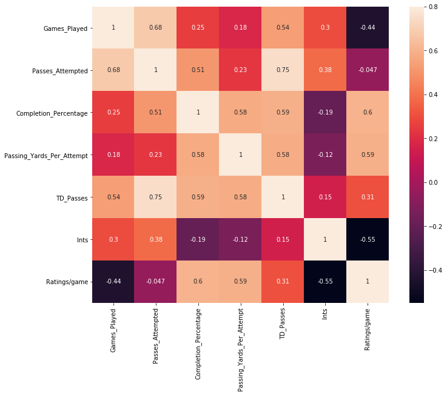

```python
corrmat = career_stats_qb_clean_new.corr()
f, ax = plt.subplots(figsize=(12, 9))
sb.heatmap(corrmat, vmax=.8, square=True, annot=True);
```